# “Report of Impact in Human Health and Economics Due to Natural Events”

# Synopsis

This report was elaborated based on U.S. National Oceanic and Atmospheric Administration’s (NOAA) storm database. It summarizes the impact of natural events in economics and human health between 1950 and 2011. The total amount of fatalities and injuries summarized by event type was the data used to determine the impact on human health. On the same line the data on properties and crop damaged was the data items used to determine the economic impact. After the analysis was completed, there was strong evidence to identify **tornados** and **excessive heat** as the type of events with *more impact on human health*. There was also strong evidence to identify **tornado** and **flash flood** as the events with the *stronger impact in economics*.

# Data Processing

This report was elaborated based on U.S. National Oceanic and Atmospheric Administration’s (NOAA) storm database, which tracks characteristics of major storms and weather events in the United States. The events in the database start in the year 1950 and end in November 2011. The start point of the analysis is the gathering of the database from the Internet. Initially, the R script developed for the analysis loads some R libraries that will be needed during the analysis, creates a working directory if it does not exist already, and downloads the NOAA database file in csv format from the Internet and load it on memory for its processing. Since the file is on bz2 zip format, the function *bzfile* is used for reading the file into memory.

```r
##
## Call some libraries that will be needed during the analysis.
##
library(RCurl)
library(plyr)
##
```

```r
##
## If working directory does not exist it creates it.
if (!file.exists("Assigment2")) {
    dir.create("Assigment2")
}

##
## If source zip file does not exist in the working directory, it is downloaded and unziped.
## Since file is rather big it save some time for repetitive runs.
##
if (!file.exists("./Assigment2/stormdata.csv.bz2")) {

    fileUrl <- "http://d396qusza40orc.cloudfront.net/repdata%2Fdata%2FStormData.csv.bz2"
    download.file(fileUrl, destfile = "./Assigment2/stormdata.csv.bz2", method = "auto")
}

##
## Loads the csv file in memory to work with it.
##

stormdata <- read.csv(bzfile("./Assigment2/stormdata.csv.bz2"), sep=",", header=T)
```

The next step is to summarize the data for the health impact. A health impact index was created to have a single picture of the impact of injuries and fatalities on a single index. For that purpose, the injury quantity was given a weight of 0.25 with respect to the fatalities. Given the massive volume of the data avaialble, only the top five hitters are extracted and consider to facilitate the analysis.

```r
health <- ddply(stormdata,.(EVTYPE), summarize,
                totfat = sum(FATALITIES),
                totinj = sum(INJURIES),
                damageidx = (sum(FATALITIES) + (sum(INJURIES) * 0.25)))

health <- arrange(health,desc(totfat))
fatality <- health[1:5,]
fatality$EVTYPE <- factor(fatality$EVTYPE, levels=fatality$EVTYPE)

health <- arrange(health,desc(totinj))
injury <- health[1:5,]
injury$EVTYPE <- factor(injury$EVTYPE, levels=injury$EVTYPE)

health <- arrange(health,desc(damageidx))
hdamage <- health[1:5,]
hdamage$EVTYPE <- factor(hdamage$EVTYPE, levels=hdamage$EVTYPE)
```

The same process if followed to determine the type of events with the higher economic impacts. In this case the impact in properties and crops are added to generate a total damage value.

```r
economic <- ddply(stormdata,.(EVTYPE), summarize,
                totprop = sum(PROPDMG),
                totcrop = sum(CROPDMG),
                damageidx = (sum(PROPDMG) + sum(CROPDMG)))

economic <- arrange(economic,desc(totprop))
property <- economic[1:5,]
property$EVTYPE <- factor(property$EVTYPE, levels=property$EVTYPE)

economic <- arrange(economic,desc(totcrop))
crop <- economic[1:5,]
crop$EVTYPE <- factor(crop$EVTYPE, levels=crop$EVTYPE)

economic <- arrange(economic,desc(damageidx))
edamage <- economic[1:5,]
edamage$EVTYPE <- factor(edamage$EVTYPE, levels=edamage$EVTYPE)
```

# Results

The plots are drawn in tandem to facilitat the analysis of the different elements on a single picture. For the health impact the **TORNADO** and the **EXCESSIVE HEAT** are the two event types with the hight impact.

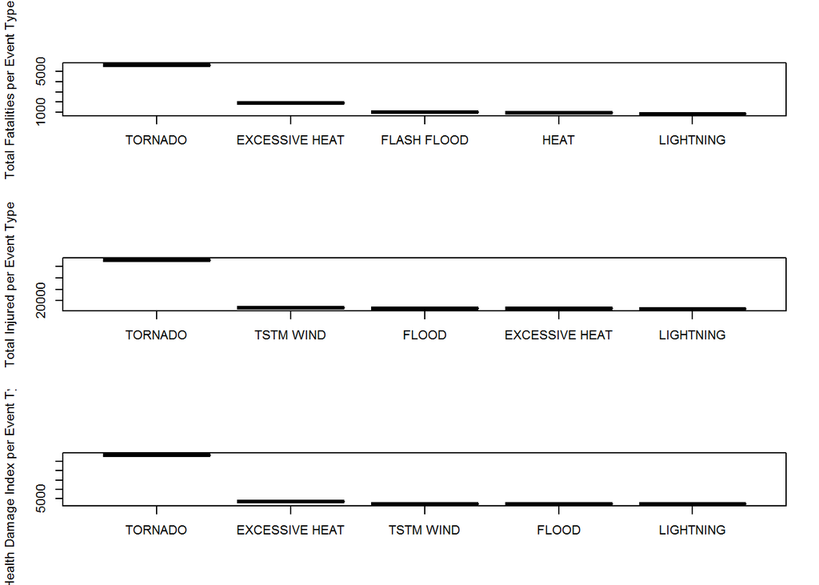

```r
par(mfcol = c(3, 1))  ## Adjust the margins and define the ploting matrix

    plot(fatality$EVTYPE, fatality$totfat,
         type="l",xlab=NA,col="blue", ylab="Total Fatalities per Event Type")


    plot(injury$EVTYPE, injury$totinj,
         type="l",xlab=NA,col="blue", ylab="Total Injured per Event Type")


    plot(hdamage$EVTYPE, hdamage$damageidx,
         type="l",xlab=NA,col="blue", ylab="Health Damage Index per Event Type")
```

For the economic impact, the **TORNADO** and the **FLASH FLOOD** are the two event types with the hight impact.

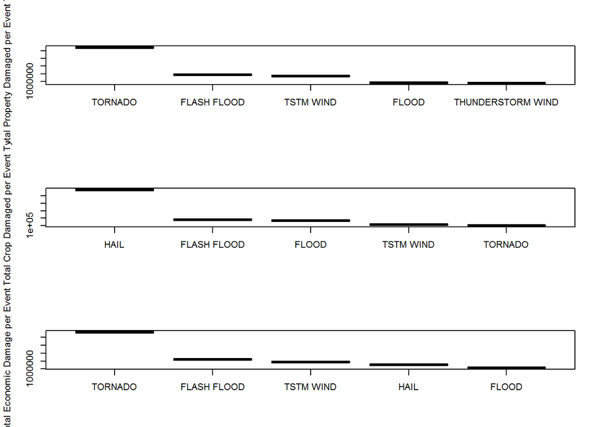

```r
par(mfcol = c(3, 1))  ## Adjust the margins and define the ploting matrix

plot(property$EVTYPE, property$totprop,
     type="l",xlab=NA,col="blue", ylab="Total Property Damaged per Event Type")


plot(crop$EVTYPE, crop$totcrop,
     type="l",xlab=NA,col="blue", ylab="Total Crop Damaged per Event Type")


plot(edamage$EVTYPE, edamage$damageidx,
     type="l",xlab=NA,col="blue", ylab="Total Economic Damage per Event Type")
```